# Target a subsidy

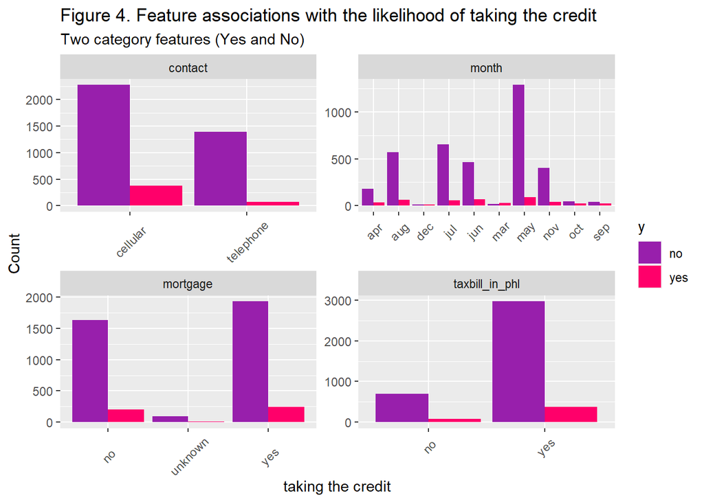

```r
housing %>%
  dplyr::select(y, mortgage, taxbill_in_phl, contact, month) %>%
  gather(Variable, value, -y) %>%
  count(Variable, value, y) %>%
  ggplot(aes(value, n, fill = y)) +
  geom_bar(position = "dodge", stat="identity") +
  facet_wrap(~Variable, scales = "free") +
  scale_fill_manual(values = palette2) +
  labs(x="taking the credit", y="Count",
       title = "Figure 4. Feature associations with the likelihood of taking the credit",
       subtitle = "Two category features (Yes and No)")+
  theme(axis.text.x = element_text(angle = 45, hjust = 0.5, vjust = 0.5))
```

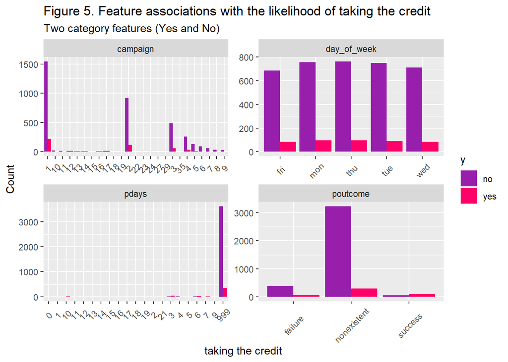

```r
housing %>%
  dplyr::select(y, day_of_week, campaign, pdays, poutcome) %>%
  gather(Variable, value, -y) %>%
  count(Variable, value, y) %>%
  ggplot(aes(value, n, fill = y)) +
  geom_bar(position = "dodge", stat="identity") +
  facet_wrap(~Variable, scales = "free") +
  scale_fill_manual(values = palette2) +
  labs(x="taking the credit", y="Count",
       title = "Figure 5. Feature associations with the likelihood of taking the credit",
       subtitle = "Two category features (Yes and No)")+
  theme(axis.text.x = element_text(angle = 45, hjust = 0.5, vjust = 0.5))
```

## Feature engineering

The Sensitivity (True Positive Rate) for a model with all the features is very low. In order to increase the sensitivity, some new features should be engineered. Based on the curve lines in Figure 2, we classified all the numeric variables into different categories. Different seasons are also classified from the month variable. The differences between each range should be significant. We also tried to classify other categorical variables, such as campaign, jobs and education. These variables are also proven to be effective in improving the sensitivity in later analysis.

```r
housing.eng<-housing%>%
  mutate(
    age.cat=case_when(age < 30 ~ "age_30",
                      age >= 30 & age < 50 ~ "age30_50",
                      age >= 50 & age < 65 ~ "age50_65",
                      age >= 65 ~ "age65+"),
    previous.cat = case_when(
      previous == 0 ~ "previous0",
      previous > 0 ~ "previousNOT0"),
    conf.cat = case_when(
      cons.conf.idx < -50 ~ "conf_50-",
      cons.conf.idx >= -50 & cons.conf.idx < -45 ~ "conf-50_-45",
      cons.conf.idx >= -45 & cons.conf.idx < -40 ~ "conf-45_-40",
      cons.conf.idx >= -40 & cons.conf.idx < -35 ~ "conf-40_-35",
      cons.conf.idx >= -35 & cons.conf.idx < -30 ~ "conf-35_-30",
      cons.conf.idx >= -30 & cons.conf.idx < -25 ~ "conf-30_-25"),
    price.cat=case_when(
      cons.price.idx < 93 ~ "price93-",
      cons.price.idx >= 93 & cons.price.idx < 93.5 ~ "price93_93.5",
      cons.price.idx >= 93.5 & cons.price.idx < 94 ~ "price93.5_94",
      cons.price.idx >= 94 & cons.price.idx < 94.5 ~ "price94_94.5",
      cons.price.idx >= 94.5 ~ "price94.5+"),
    inflation.cat = case_when(
      inflation_rate >= 0.5 & inflation_rate < 1.5 ~ "inflation0.5_1.5",
      inflation_rate >= 1.5 & inflation_rate < 2.5 ~ "inflation1.5_2.5",
      inflation_rate >= 2.5 & inflation_rate < 3.5 ~ "inflation2.5_3.5",
      inflation_rate >= 3.5 & inflation_rate < 4.5 ~ "inflation3.5_4.5",
      inflation_rate >= 4.5 ~ "inflation4.5+"),
    repair.cat=case_when(
      spent_on_repairs < 5000 ~ "repair5000-",
      spent_on_repairs >= 5000 & spent_on_repairs < 5100 ~ "repair5000_5100",
      spent_on_repairs >= 5100 & spent_on_repairs < 5200 ~ "repair5100_5200",
      spent_on_repairs >= 5200 ~ "repair5200+"),
    season = case_when(
      month == "mar"| month == "apr"| month == "may" ~ "Spring",
      month == "jun" | month == "jul" | month == "aug"~ "Summer",
      month == "sep"| month == "oct" | month == "nov" ~ "Fall",
      month == "dec" ~ "Winter"),
    education.cat = case_when(
      education == "basic.4y" | education == "basic.6y" | education == "basic.9y" ~ "Basic",
      education == "high.school" ~ "HighSchool",
      education == "professional.course" ~ "Professional",
      education == "university.degree" ~ "University",
      education == "illiterate" ~ "Illiterate",
      education == "unknown" ~ "Unknown"),
    job.cat = ifelse(job == "self-employed"|job =="unemloyed", "Self_or_unemployed",
                     "Other"),
    campaign.cat = case_when(
      campaign >= 0 & campaign < 2  ~ "Once",
      campaign >= 2 & campaign < 10  ~ "2 to 9 times",
      campaign > 9                    ~ "More than 9 times")
  )
```

Figure 6 shows those new engineered features with the likelihood of taking the credit. The gap between whether taking credits or not is still large, though decreasing slightly. Generally, those houseowners are more likely to take the credits: houseowners aged from 30 to 50, houseowners whose consumer confidence index ranges from -35 to -45, houseowners whose US inflation rate is 0.5 to 1.5, houseowners whose price index is below 93, houseowners who spent 5000 to 5100 dollars on home repairs, houseowners whose number of contacts is less than nine for this campaign, houseowners whose education attainment is university, and houseowners who are contacted in summer. To further test the most significant variables affecting the decision of houseowners, the Logistic regression model will be applied in the following analysis.

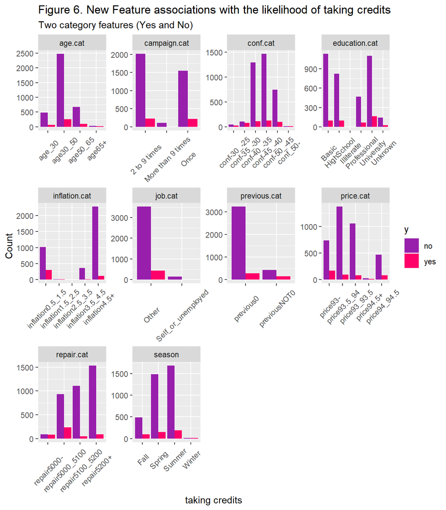

```r
#Interpret your new features
housing.eng%>%
  dplyr::select(y, age.cat, previous.cat, price.cat, conf.cat, inflation.cat, repair.cat,season,education.cat,job.cat,campaign.cat) %>%
  gather(Variable, value, -y) %>%
  count(Variable, value, y) %>%
  ggplot(aes(value, n, fill = y)) +
  geom_bar(position = "dodge", stat="identity") +
  facet_wrap(~Variable, scales = "free") +
  scale_fill_manual(values = palette2) +
  labs(x="taking credits", y="Count",
       title = "Figure 6. New Feature associations with the likelihood of taking credits",
       subtitle = "Two category features (Yes and No)")+
  theme(axis.text.x = element_text(angle = 45, hjust = 0.5, vjust = 0.5))
```

## Logistic regression

### Training/Testing sets

In order to conduct the Logistic regression model for estimation, first of all, the dataset is split into a 65/35 training/test set. Then based on the training/test set, two logistic regression models were built. One is called the kitchen sink regression, which selects all the original, untransformed variables. It consists of both numeric and categorical variables; the other is called as the engineered regression, which picks some engineering features and orginal categorical variables. Keeping in mind that the sensitivity should be improved as possible, we went through several trials, changed the variables in this model and finally, include the following variables in the engineered regression model: age.cat, previous.cat, price.cat, conf.cat, inflation.cat, job.cat, marital, education.cat,taxLien, mortgage, taxbill_in_phl, contact, day_of_week, campaign, pdays, season, poutcome,campaign.cat. Both the kitchen sink and engineered model’s dataset is also split into test and training set.

```r
#Split your data into a 65/35 training/test set.
set.seed(3456)
trainIndex <- createDataPartition(housing.eng$y,
                                  y=paste(
                                    housing.eng$education,
                                    housing.eng$taxLien
                                          ),
                                  p = .65,
                                  list = FALSE,
                                  times = 1)
housingTrain <- housing.eng[ trainIndex,]
housingTest  <- housing.eng[-trainIndex,]

#kitchen sink
kitchenTrain<-housingTrain%>%
  dplyr::select(y,y_numeric,age, previous, unemploy_rate,
                cons.price.idx, cons.conf.idx, inflation_rate, spent_on_repairs,
                job, marital, education,taxLien,
                mortgage, taxbill_in_phl, contact, month,
                day_of_week, campaign, pdays, poutcome)

kitchenTest<-housingTest%>%
  dplyr::select(y,y_numeric,age, previous, unemploy_rate,
                cons.price.idx, cons.conf.idx, inflation_rate, spent_on_repairs,
                job, marital, education,taxLien,
                mortgage, taxbill_in_phl, contact, month,
                day_of_week, campaign, pdays, poutcome)

#engineering
engTrain<-housingTrain%>%
  dplyr::select(
    y,y_numeric,age.cat, previous.cat, price.cat, conf.cat, inflation.cat,
    job.cat, marital, education.cat,taxLien,
    mortgage, taxbill_in_phl, contact,
    day_of_week, campaign, pdays, season, poutcome,campaign.cat
  )

engTest<-housingTest%>%
  dplyr::select(
    y,y_numeric,age.cat, previous.cat, price.cat, conf.cat, inflation.cat,
    job.cat, marital, education.cat,taxLien,
    mortgage, taxbill_in_phl, contact,
    day_of_week, campaign, pdays, season, poutcome,campaign.cat
  )
```